# sp.scRNAseq sensivity testing

Jason T. Serviss

24/10/2016

## Introduction

To test the sensivity of the sp.scRNAseq package the “synthetic dataset” was used to run 2 tests.

1. Multuplet gene expression values were gradually replaced with random values and sp.scRNAseq was run after each replacment.
2. The number of samples (cell types) in each group was gradually reduced and sp.scRNAseq was run after each reduction.

## Synthetic dataset

The synthetic dataset is comprised of 10 cell types, with 100 individual cells per cell type. Each cell has expression values for 2000 genes.

## Test 1

In the first test we gradually replace gene expression values in the multuplets with random noise. For each percentage of random data 10 multuplets consisting of 2, 3, and 4 cells were randomly picked and run. The results indicate that only 20% of the gene expression values are necessary for sp.scRNAseq to determine the correct results.

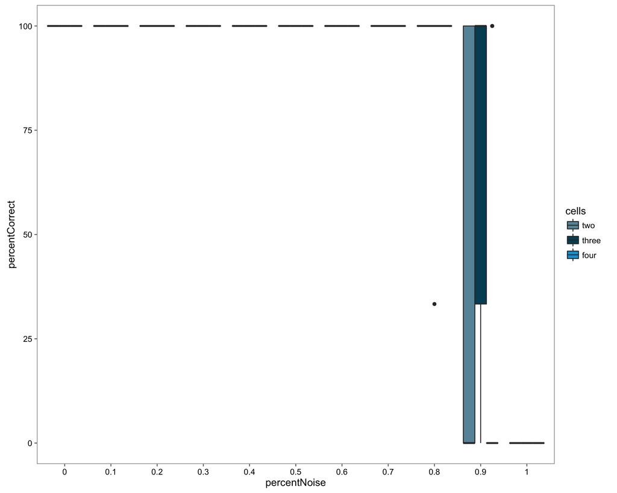

```r
noiseDataTestPlot()
```

## Test 2

In the second test, we remove 10 of the samples from each cell type each iteration. sp.scRNAseq is then run for 6 multuplets (2 consisting of 2 cells, 2 consisting of 3 cells, and 2 consisting of 4 cells). The results indicate that performance drops quite quickly and already at 90 samples per cell type sp.scRNAseq is not capable of determining correct results under all conditions.

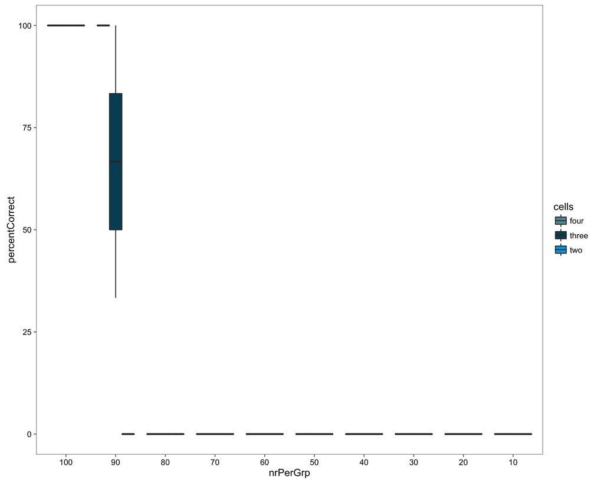

```r
plotGroupSizeTest()
```

## Functions

### noiseDataTest

```r
noiseDataTest <-
function (innerCores = 1, outerCores = 10, outPath = "data",
    n = 10, ...)
{
    tmp <- .generateNoiseData(n)
    noise <- tmp[[1]]
    names <- tmp[[2]]
    noisePercent <- dimnames(noise)[[3]]
    multCellNr <- dimnames(noise)[[4]]
    uObj <- syntheticDataUnsupervised
    results <- list()
    if (outerCores > 1) {
        registerDoMC(outerCores)
    }
    for (i in 1:dim(noise)[4]) {
        currMultNumb <- noise[, , , i]
        currNames <- names[, , , i]
        inner <- foreach(u = 1:dim(currMultNumb)[3]) %dopar%
            {
                currMatrix <- currMultNumb[, , u]
                colnames(currMatrix) <- currNames[, u]
                cObj <- spCounts(counts = currMatrix, counts.ercc = matrix(),
                  sampleType = "m.")
                noiseDataSwarm <- spSwarm(cObj, uObj, limit = "none",
                  maxiter = 10, swarmsize = 250, cores = innerCores)
            }
        results[[i]] <- inner
    }
    if (outerCores > 1) {
        registerDoSEQ()
    }
    names(results) <- multCellNr
    names(results[[1]]) <- noisePercent
    names(results[[2]]) <- noisePercent
    names(results[[3]]) <- noisePercent
    noiseData <- tmp
    noiseDataSwarm <- results
    noiseDataUnsupervised <- syntheticDataUnsupervised
    save(noiseData, file = paste(outPath, "noiseData.rda", sep = "/"),
        compress = "bzip2")
    save(noiseDataUnsupervised, file = paste(outPath, "noiseDataUnsupervised.rda",
        sep = "/"), compress = "bzip2")
    save(noiseDataSwarm, file = paste(outPath, "noiseDataSwarm.rda",
        sep = "/"), compress = "bzip2")
    return(noiseDataSwarm)
}
```

#### .generateNoiseData

```r
.generateNoiseData <-
function (n)
{
    set.seed(11)
    data(syntheticData)
    multuplets <- syntheticData[, grep("m.", colnames(syntheticData))]
    tmp <- multuplets[, nchar(colnames(multuplets)) == 6]
    two <- tmp[, sample(1:ncol(tmp), n, replace = FALSE)]
    tmp <- multuplets[, nchar(colnames(multuplets)) == 8]
    three <- tmp[, sample(1:ncol(tmp), n, replace = FALSE)]
    tmp <- multuplets[, nchar(colnames(multuplets)) == 10]
    four <- tmp[, sample(1:ncol(tmp), n, replace = FALSE)]
    noise <- array(NA, dim = c(nrow(multuplets), n, 11, 3))
    dimnames(noise)[[3]] <- as.character(seq(0, 1, 0.1))
    dimnames(noise)[[4]] <- c("two", "three", "four")
    names <- array(NA, dim = c(1, n, 11, 3))
    names[, , , 1] <- colnames(two)
    names[, , , 2] <- colnames(three)
    names[, , , 3] <- colnames(four)
    noise[, , 1, "two"] <- two
    noise[, , 1, "three"] <- three
    noise[, , 1, "four"] <- four
    percent <- seq(0.1, 1, 0.1)
    for (i in 1:length(percent)) {
        tmp <- two
        nRows <- nrow(syntheticData) * percent[i]
        picked <- sample(1:nrow(multuplets), nRows, replace = FALSE)
        sub <- two[picked, ]
        reordered <- sub[sample.int(nrow(sub)), ]
        tmp[picked, ] <- reordered
        noise[, , i + 1, "two"] <- tmp
    }
    for (i in 1:length(percent)) {
        tmp <- three
        nRows <- nrow(syntheticData) * percent[i]
        picked <- sample(1:nrow(multuplets), nRows, replace = FALSE)
        sub <- three[picked, ]
        reordered <- sub[sample.int(nrow(sub)), ]
        tmp[picked, ] <- reordered
        noise[, , i + 1, "three"] <- tmp
    }
    for (i in 1:length(percent)) {
        tmp <- four
        nRows <- nrow(syntheticData) * percent[i]
        picked <- sample(1:nrow(multuplets), nRows, replace = FALSE)
        sub <- four[picked, ]
        reordered <- sub[sample.int(nrow(sub)), ]
        tmp[picked, ] <- reordered
        noise[, , i + 1, "four"] <- tmp
    }
    noiseData <- list(noise, names)
    return(noiseData)
}
```

### noiseDataTestPlot

```r
noiseDataTestPlot <-
function ()
{
    data(noiseDataSwarm)
    df <- .formatNoiseResults(noiseDataSwarm)
    pc <- .addPercentCorrect(df)
    ggplot(pc, aes(x = percentNoise, y = percentCorrect, fill = cells)) +
        geom_boxplot() + theme_few() + scale_fill_economist()
}
```

#### .formatNoiseResults

```r
.formatNoiseResults <-
function (results)
{
    d <- lapply(noiseDataSwarm, function(x) lapply(x, function(y) getData(y,
        "spSwarm")))
    c <- lapply(1:length(d), function(x) lapply(1:length(d[[x]]),
        function(y) cbind(d[[x]][[y]], data.frame(cells = rep(names(d)[x],
            nrow(d[[x]][[y]]))))))
    n <- lapply(1:length(c), function(x) lapply(1:length(c[[x]]),
        function(y) cbind(c[[x]][[y]], data.frame(percentNoise = rep(names(d[[1]])[y],
            nrow(d[[x]][[y]]))))))
    data <- data.frame()
    for (o in 1:length(n)) {
        data <- rbind(data, rbind.fill(n[[o]]))
    }
    return(data)
}
```

#### .addPercentCorrect

```r
.addPercentCorrect <-
function (data)
{
    realConn1 <- gsub("m.([A-Z]1[A-Z]1)", "\\1", data$sampleName)
    realConn2 <- gsub("(.{2})", "\\1 ", realConn1)
    realConn3 <- trimws(realConn2, which = "both")
    realConn4 <- strsplit(realConn3, " ")
    realConn5 <- lapply(realConn4, function(x) combn(x, 2))
    realConn6 <- lapply(realConn5, function(u) sapply(1:ncol(u),
        function(t) paste(u[1, t], u[2, t], sep = "-")))
    detConn <- list()
    for (u in 1:nrow(data)) {
        coln <- c("A1", "B1", "C1", "D1", "E1", "F1", "G1", "H1",
            "I1", "J1")
        currDetConn <- data.frame(t(data[u, coln]))
        if (data[u, "cells"] == "two") {
            threshold <- (1/2 - 0.02)
        }
        if (data[u, "cells"] == "three") {
            threshold <- (1/3 - 0.02)
        }
        if (data[u, "cells"] == "four") {
            threshold <- (1/4 - 0.02)
        }
        pick <- rownames(currDetConn)[which(currDetConn[, 1] >=
            threshold)]
        if (length(pick) < 2) {
            pick <- combn(matrix(c(NA, NA), nrow = 2), 2)
        }
        conn <- combn(pick, 2)
        detConn[[u]] <- sapply(1:ncol(conn), function(g) paste(conn[1,
            g], conn[2, g], sep = "-"))
    }
    t <- lapply(detConn, function(y) if (length(y) == 1) {
        if (y == "NA-NA") {
            NA
        }
        else {
            y
        }
    }
    else {
        y
    })
    correct <- lapply(1:length(realConn6), function(i) length(which(realConn6[[i]] %in%
        detConn[[i]] == TRUE)))
    total <- lapply(realConn6, function(i) length(i))
    percent <- lapply(1:length(total), function(g) 100 * correct[[g]]/total[[g]])
    data$percentCorrect <- as.numeric(percent)
    return(data)
}
```

### groupSizeTest

```r
groupSizeTest <-
function (...)
{
    multNames <- c("m.A1B1", "m.I1J1", "m.A1B1C1", "m.H1I1J1",
        "m.A1B1C1D1", "m.G1H1I1J1")
    sngNames <- paste("s.", LETTERS[1:10], 1, sep = "")
    sng <- syntheticData[, 1:1000]
    mult <- syntheticData[, colnames(syntheticData) %in% multNames]
    s <- seq(100, 10, -10)
    groupSizeTestcObj <- list()
    groupSizeTestuObj <- list()
    groupSizeTestsObj <- list()
    for (i in 1:length(s)) {
        if (i == 1) {
            testCounts <- cbind(sng, mult)
        }
        else {
            for (o in 1:length(sngNames)) {
                currName <- sngNames[o]
                currData <- sng[, grepl(currName, colnames(sng))][,
                  1:s[i]]
                if (o == 1) {
                  testCounts <- currData
                }
                else {
                  testCounts <- cbind(testCounts, currData)
                }
            }
            testCounts <- cbind(testCounts, mult)
        }
        cObj <- spCounts(testCounts, matrix(), "m.")
        uObj <- spUnsupervised(cObj, max = 1000, max_iter = 1000)
        sObj <- spSwarm(uObj, limit = "none", maxiter = 10, swarmsize = 250,
            cores = 6)
        groupSizeTestcObj[[i]] <- cObj
        groupSizeTestuObj[[i]] <- uObj
        groupSizeTestsObj[[i]] <- sObj
    }
    names(groupSizeTestcObj) <- as.character(s)
    names(groupSizeTestuObj) <- as.character(s)
    names(groupSizeTestsObj) <- as.character(s)
    save(groupSizeTestcObj, groupSizeTestuObj, groupSizeTestsObj,
        file = "data/groupSizeTest.rda", compress = "bzip2")
    return(spSwarmResults)
}
```

### plotGroupSizeTest

```r
plotGroupSizeTest <-
function (...)
{
    df <- .processGroupSizeTest(groupSizeTestsObj)
    plot <- .addPercentCorrect(df)
    p <- .plotGroupSizeProcessedRes(plot)
    p
    return(p)
}
```

#### .processGroupSizeTest

```r
.processGroupSizeTest <-
function (data)
{
    res <- data.frame()
    for (i in 1:length(data)) {
        res <- rbind(res, rbind.fill(getData(groupSizeTestsObj[[i]],
            "spSwarm")))
    }
    res$nrPerGrp <- sort(factor(rep(names(data), 6), levels = as.character(seq(100,
        10, -10))), decreasing = FALSE)
    res$cells <- ifelse(nchar(res$sampleName) == 6, "two", ifelse(nchar(res$sampleName) ==
        8, "three", "four"))
    return(res)
}
```

#### .plotGroupSizeProcessedRes

```r
.plotGroupSizeProcessedRes <-
function (data)
{
    p <- ggplot(data, aes(x = nrPerGrp, y = percentCorrect, fill = cells)) +
        geom_boxplot() + theme_few() + scale_fill_economist()
    return(p)
}
```